# Data Summarization

## Data Summarization

- Basic statistical summarization
  - `mean(x)`: takes the mean of x
  - `sd(x)`: takes the standard deviation of x
  - `median(x)`: takes the median of x
  - `quantile(x)`: displays sample quantiles of x. Default is min, IQR, max
  - `range(x)`: displays the range. Same as `c(min(x), max(x))`
  - `sum(x)`: sum of x
  - `max(x)`: maximum value in x
  - `min(x)`: minimum value in x
  - **all have a** `na.rm` for missing data
- Transformations
  - `log` - log (base `e`) transformation
  - `log10` - log base 10 transform
  - `sqrt` - square root

## Statistical summarization

The vector getting summarized goes inside the parentheses:

```r
x <- c(1, 5, 7, 4, 2, 8)
mean(x)
```

```
[1] 4.5
```

```r
range(x)
```

```
[1] 1 8
```

```r
sum(x)
```

```
[1] 27
```

## Statistical summarization

Note that many of these functions have additional inputs regarding missing data, typically requiring the `na.rm` argument (“remove NAs”).

```r
x <- c(1, 5, 7, 4, 2, 8, NA)
mean(x)
```

```
[1] NA
```

```r
mean(x, na.rm = TRUE)
```

```
[1] 4.5
```

```r
quantile(x)
```

```
Error in quantile.default(x): missing values and NaN's not allowed if 'na.rm' is FALSE
```

```r
quantile(x, na.rm = TRUE)
```

```
  0%  25%  50%  75% 100%
 1.0  2.5  4.5  6.5  8.0
```

## Statistical summarization

We will talk more about data types later, but you can only do summarization on numeric or logical types. Not characters or factors.

```r
x <- c(1, 5, 7, 4, 2, 8)
sum(x)
```

```
[1] 27
```

```r
y <- c(TRUE, FALSE, FALSE, TRUE) # FALSE == 0 and TRUE == 1
sum(y)
```

```
[1] 2
```

```r
z <- c("TRUE", "FALSE", "FALSE", "TRUE")
sum(z)
```

```
Error in sum(z): invalid 'type' (character) of argument
```

```r
mean(z)
```

```
Warning in mean.default(z): argument is not numeric or logical: returning NA
```

```
[1] NA
```

## Some examples

We can use the `jhu_cars` to explore different ways of summarizing data. The `head` command displays the first rows of an object:

```r
library(jhur)
head(jhu_cars)
```

```
                car  mpg cyl disp  hp drat    wt  qsec vs am gear carb
1         Mazda RX4 21.0   6  160 110 3.90 2.620 16.46  0  1    4    4
2     Mazda RX4 Wag 21.0   6  160 110 3.90 2.875 17.02  0  1    4    4
3        Datsun 710 22.8   4  108  93 3.85 2.320 18.61  1  1    4    1
4    Hornet 4 Drive 21.4   6  258 110 3.08 3.215 19.44  1  0    3    1
5 Hornet Sportabout 18.7   8  360 175 3.15 3.440 17.02  0  0    3    2
6           Valiant 18.1   6  225 105 2.76 3.460 20.22  1  0    3    1
```

## Statistical summarization

Note - the `$` references/selects columns from a `data.frame`/`tibble`:

```r
mean(jhu_cars$hp)
```

```
[1] 146.6875
```

```r
quantile(jhu_cars$hp)
```

```
   0%   25%   50%   75%  100%
 52.0  96.5 123.0 180.0 335.0
```

## Statistical summarization

The “tidy” way:

```r
jhu_cars %>% pull(hp) %>% mean() # alt: pull(jhu_cars, hp) %>% mean()
```

```
[1] 146.6875
```

```r
jhu_cars %>% pull(hp) %>% quantile()
```

```
   0%   25%   50%   75%  100%
 52.0  96.5 123.0 180.0 335.0
```

## Statistical summarization

```r
jhu_cars %>% pull(wt) %>% median()
```

```
[1] 3.325
```

```r
jhu_cars %>% pull(wt) %>% quantile(probs = 0.6)
```

```
 60%
3.44
```

## Data Summarization on data frames

- Basic statistical summarization
  - `rowMeans(x)`: takes the means of each row of x
  - `colMeans(x)`: takes the means of each column of x
  - `rowSums(x)`: takes the sum of each row of x
  - `colSums(x)`: takes the sum of each column of x
  - `summary(x)`: for data frames, displays the quantile information

## TB Incidence

Let’s read in a `tibble` of values from TB incidence.

If you have the `jhur` package installed successfully:

```r
tb <- jhur::read_tb()
```

## TB Incidence

Check out the data:

```r
head(tb)
```

```
# A tibble: 6 x 19
  `TB incidence, all fo… `1990` `1991` `1992` `1993` `1994` `1995` `1996` `1997`
  <chr>                   <dbl>  <dbl>  <dbl>  <dbl>  <dbl>  <dbl>  <dbl>  <dbl>
1 Afghanistan               168    168    168    168    168    168    168    168
2 Albania                    25     24     25     26     26     27     27     28
3 Algeria                    38     38     39     40     41     42     43     44
4 American Samoa             21      7      2      9      9     11      0     12
5 Andorra                    36     34     32     30     29     27     26     26
6 Angola                    205    209    214    218    222    226    231    236
# … with 10 more variables: 1998 <dbl>, 1999 <dbl>, 2000 <dbl>, 2001 <dbl>,
#   2002 <dbl>, 2003 <dbl>, 2004 <dbl>, 2005 <dbl>, 2006 <dbl>, 2007 <dbl>
```

```r
colnames(tb)
```

```
 [1] "TB incidence, all forms (per 100 000 population per year)"
 [2] "1990"
 [3] "1991"
 [4] "1992"
 [5] "1993"
 [6] "1994"
 [7] "1995"
 [8] "1996"
 [9] "1997"
[10] "1998"
[11] "1999"
[12] "2000"
[13] "2001"
[14] "2002"
[15] "2003"
[16] "2004"
[17] "2005"
[18] "2006"
[19] "2007"
```

## Indicator of TB

Before we go further, let’s rename the first column to be the country measured using the `rename` function in `dplyr`.

In this case, we have to use the backticks (`) because there are spaces and funky characters in the name:

```r
library(dplyr)
tb <- tb %>% rename(country = `TB incidence, all forms (per 100 000 population per year)`)
```

`colnames` will show us the column names and show that country is renamed:

```r
colnames(tb)
```

```
 [1] "country" "1990"    "1991"    "1992"    "1993"    "1994"    "1995"
 [8] "1996"    "1997"    "1998"    "1999"    "2000"    "2001"    "2002"
[15] "2003"    "2004"    "2005"    "2006"    "2007"
```

## Summarize the data: `dplyr` `summarize` function

`dplyr::summarize` will allow you to summarize data. Format is `new = SUMMARY`.

```r
# General format - Not the code!
{data object to update} <- {data to use} %>%
                          summarize({summary column name} = {operator(source column)})
```

```r
tb %>% summarize(mean_2006 = mean(`2006`, na.rm = TRUE))
```

```
# A tibble: 1 x 1
  mean_2006
      <dbl>
1      135.
```

## Summarize the data: `dplyr` `summarize` function

`summarize` can do multiple operations at once. Just separate by a comma.

```r
tb %>%
  summarize(mean_2006 = mean(`2006`, na.rm = TRUE),
            median_2007 = median(`2007`, na.rm = TRUE),
            median(`2004`, na.rm = TRUE))
```

```
# A tibble: 1 x 3
  mean_2006 median_2007 `median(\`2004\`, na.rm = TRUE)`
      <dbl>       <dbl>                            <dbl>
1      135.          53                               56
```

Notice how when we forget to provide a new name, output is still provided, but the column name is messy.

## Iterative summaries: `dplyr` `summarize` and `across` functions

Use the [`across`](https://dplyr.tidyverse.org/reference/across.html) function with `summarize` to summarize across multiple columns of your data.

```r
tb %>%
  summarize(across( c(`1990`, `1991`, `1992`, `1993`), ~ sum(.x, na.rm = TRUE)))
```

```
# A tibble: 1 x 4
  `1990` `1991` `1992` `1993`
   <dbl>  <dbl>  <dbl>  <dbl>
1  21855  22288  22421  22836
```

```r
tb %>%
  summarize(across( starts_with("2"), ~ range(.x, na.rm = TRUE)))
```

```
# A tibble: 2 x 8
  `2000` `2001` `2002` `2003` `2004` `2005` `2006` `2007`
   <dbl>  <dbl>  <dbl>  <dbl>  <dbl>  <dbl>  <dbl>  <dbl>
1      0      0      3      0      0      0      0      0
2    801    916    994   1075   1127   1141   1169   1198
```

## Row means

`colMeans` and `rowMeans` require **all numeric data**.

Let’s see what the mean is across each row (country):

```r
tb_2 <- column_to_rownames(tb, "country") # opposite of rownames_to_column() !
head(tb_2, 2)
```

```
            1990 1991 1992 1993 1994 1995 1996 1997 1998 1999 2000 2001 2002
Afghanistan  168  168  168  168  168  168  168  168  168  168  168  168  168
Albania       25   24   25   26   26   27   27   28   28   27   25   23   23
            2003 2004 2005 2006 2007
Afghanistan  168  168  168  168  168
Albania       22   21   20   18   17
```

```r
rowMeans(tb_2, na.rm = TRUE)
```

```
                     Afghanistan                          Albania
                      168.000000                        24.000000
                         Algeria                   American Samoa
                       46.388889                         7.611111
                         Andorra                           Angola
                       24.944444                       243.888889
                        Anguilla              Antigua and Barbuda
                       22.833333                         7.222222
                       Argentina                          Armenia
                       43.666667                        57.611111
                       Australia                          Austria
                        6.444444                        16.333333
                      Azerbaijan                          Bahamas
                       61.388889                        44.000000
                         Bahrain                       Bangladesh
                       53.222222                       242.666667
                        Barbados                          Belarus
                        4.833333                        57.166667
                         Belgium                           Belize
                       16.000000                        40.000000
                           Benin                          Bermuda
                       83.500000                         4.833333
                          Bhutan                          Bolivia
                      375.111111                       200.611111
          Bosnia and Herzegovina                         Botswana
                       72.111111                       568.777778
                          Brazil           British Virgin Islands
                       64.277778                        13.333333
               Brunei Darussalam                         Bulgaria
                       63.500000                        39.055556
                    Burkina Faso                          Burundi
                      175.777778                       285.333333
                        Cambodia                         Cameroon
                      538.944444                       149.055556
                          Canada                       Cape Verde
                        6.722222                       162.666667
                  Cayman Islands         Central African Republic
                        4.833333                       268.333333
                            Chad                            Chile
                      232.277778                        22.722222
                           China                         Colombia
                      107.000000                        43.611111
                         Comoros                      Congo, Rep.
                       61.388889                       313.555556
                    Cook Islands                       Costa Rica
                       12.000000                        14.333333
                         Croatia                             Cuba
                       56.722222                        13.833333
                          Cyprus                   Czech Republic
                        6.444444                        16.277778
                   Cote d'Ivoire                 Korea, Dem. Rep.
                      327.000000                       344.000000
                Congo, Dem. Rep.                          Denmark
                      304.611111                        10.555556
                        Djibouti                         Dominica
                      691.444444                        14.000000
              Dominican Republic                          Ecuador
                       89.944444                       131.444444
                           Egypt                      El Salvador
                       29.111111                        58.444444
               Equatorial Guinea                          Eritrea
                      199.055556                        83.111111
                         Estonia                         Ethiopia
                       49.888889                       294.000000
                            Fiji                          Finland
                       33.666667                        10.944444
                          France                 French Polynesia
                       18.277778                        36.222222
                           Gabon                           Gambia
                      230.277778                       219.777778
                         Georgia                          Germany
                       67.055556                        12.888889
                           Ghana                           Greece
                      212.722222                        23.500000
                         Grenada                             Guam
                        4.277778                        44.222222
                       Guatemala                           Guinea
                       68.777778                       191.833333
                   Guinea-Bissau                           Guyana
                      187.055556                        75.611111
                           Haiti                         Honduras
                      306.000000                        77.055556
                         Hungary                          Iceland
                       36.666667                         4.111111
                           India                        Indonesia
                      168.000000                       281.777778
                            Iran                             Iraq
                       32.277778                        56.000000
                         Ireland                           Israel
                       16.444444                         9.944444
                           Italy                          Jamaica
                        9.722222                         7.000000
                           Japan                           Jordan
                       34.777778                        10.833333
                      Kazakhstan                            Kenya
                      103.666667                       303.444444
                        Kiribati                           Kuwait
                      435.111111                        31.222222
                      Kyrgyzstan                             Laos
                      103.055556                       164.500000
                          Latvia                          Lebanon
                       63.444444                        32.555556
                         Lesotho                          Liberia
                      451.944444                       235.833333
          Libyan Arab Jamahiriya                        Lithuania
                       23.888889                        65.000000
                      Luxembourg                       Madagascar
                       16.166667                       212.055556
                          Malawi                         Malaysia
                      375.444444                       110.722222
                        Maldives                             Mali
                       81.444444                       296.388889
                           Malta                       Mauritania
                        7.833333                       270.333333
                       Mauritius                           Mexico
                       24.944444                        37.055556
           Micronesia, Fed. Sts.                           Monaco
                      138.055556                         3.000000
                        Mongolia                       Montenegro
                      205.000000                        32.500000
                      Montserrat                          Morocco
                        8.277778                       118.166667
                      Mozambique                          Myanmar
                      335.444444                       171.000000
                         Namibia                            Nauru
                      596.222222                        91.388889
                           Nepal                      Netherlands
                      206.055556                         9.888889
            Netherlands Antilles                    New Caledonia
                        9.833333                        47.777778
                     New Zealand                        Nicaragua
                        9.555556                        74.611111
                           Niger                          Nigeria
                      148.333333                       241.666667
                            Niue         Northern Mariana Islands
                       41.444444                        98.833333
                          Norway                             Oman
                        7.277778                        14.388889
                        Pakistan                            Palau
                      181.000000                        83.166667
                          Panama                 Papua New Guinea
                       47.000000                       250.000000
                        Paraguay                             Peru
                       59.222222                       207.888889
                     Philippines                           Poland
                      339.277778                        40.111111
                        Portugal                      Puerto Rico
                       49.722222                         8.166667
                           Qatar                      Korea, Rep.
                       63.833333                        96.666667
                         Moldova                          Romania
                      112.166667                       118.277778
              Russian Federation                           Rwanda
                       87.222222                       308.777778
           Saint Kitts and Nevis                      Saint Lucia
                        9.777778                        15.055556
Saint Vincent and the Grenadines                            Samoa
                       26.000000                        24.777778
                      San Marino            Sao Tome and Principe
                        8.222222                       117.388889
                    Saudi Arabia                          Senegal
                       43.500000                       231.055556
                      Seychelles                     Sierra Leone
                       37.555556                       361.444444
                       Singapore                         Slovakia
                       40.388889                        30.777778
                        Slovenia                  Solomon Islands
                       26.444444                       207.333333
                         Somalia                     South Africa
                      249.000000                       556.333333
                           Spain                        Sri Lanka
                       39.111111                        60.000000
                           Sudan                         Suriname
                      207.000000                        75.166667
                       Swaziland                           Sweden
                      679.555556                         5.944444
                     Switzerland             Syrian Arab Republic
                       11.000000                        39.388889
                      Tajikistan                         Thailand
                      121.777778                       142.000000
                  Macedonia, FYR                      Timor-Leste
                       41.277778                       322.000000
```

```
                            Togo                          Tokelau
                      365.333333                        35.611111
                           Tonga              Trinidad and Tobago
                       28.722222                        11.000000
                         Tunisia                           Turkey
                       27.666667                        36.777778
                    Turkmenistan         Turks and Caicos Islands
                       72.500000                        18.055556
                          Tuvalu                           Uganda
                      225.555556                       322.611111
                         Ukraine             United Arab Emirates
                       72.611111                        20.833333
                  United Kingdom                         Tanzania
                       12.555556                       290.500000
           Virgin Islands (U.S.)         United States of America
                       13.277778                         6.666667
                         Uruguay                       Uzbekistan
                       24.888889                        89.944444
                         Vanuatu                        Venezuela
                      105.277778                        34.444444
                        Viet Nam                 Wallis et Futuna
                      186.333333                        68.833333
              West Bank and Gaza                            Yemen
                       27.666667                       106.000000
                          Zambia                         Zimbabwe
                      535.944444                       608.222222
```

`colMeans` gives you very similar output to functions we’ve seen previously in this lecture (`summarize` and `across`).

```r
colMeans(tb_2, na.rm = TRUE)
```

```
    1990     1991     1992     1993     1994     1995     1996     1997
105.5797 107.6715 108.3140 110.3188 111.9662 114.1981 115.3527 118.8792
    1998     1999     2000     2001     2002     2003     2004     2005
121.5169 125.0435 127.8454 130.7488 136.1739 136.1932 136.9662 135.6683
    2006     2007
134.6106 133.3865
```

```r
tb_2 %>%
  summarize(across( colnames(tb_2), ~ mean(.x, na.rm = TRUE)))
```

```
      1990     1991    1992     1993     1994     1995     1996     1997
1 105.5797 107.6715 108.314 110.3188 111.9662 114.1981 115.3527 118.8792
      1998     1999     2000     2001     2002     2003     2004     2005
1 121.5169 125.0435 127.8454 130.7488 136.1739 136.1932 136.9662 135.6683
      2006     2007
1 134.6106 133.3865
```

## `summary` Function

Using `summary` can give you rough snapshots of each column, but you would likely use `mean`, `min`, `max`, and `quantile` when necessary (and number of NAs):

```r
summary(tb)
```

```
   country               1990            1991            1992
 Length:208         Min.   :  0.0   Min.   :  4.0   Min.   :  2.0
 Class :character   1st Qu.: 27.5   1st Qu.: 27.0   1st Qu.: 27.0
 Mode  :character   Median : 60.0   Median : 58.0   Median : 56.0
                    Mean   :105.6   Mean   :107.7   Mean   :108.3
                    3rd Qu.:165.0   3rd Qu.:171.0   3rd Qu.:171.5
                    Max.   :585.0   Max.   :594.0   Max.   :606.0
                    NA's   :1       NA's   :1       NA's   :1
      1993            1994          1995            1996            1997
 Min.   :  4.0   Min.   :  0   Min.   :  3.0   Min.   :  0.0   Min.   :  0.0
 1st Qu.: 27.5   1st Qu.: 26   1st Qu.: 26.5   1st Qu.: 25.5   1st Qu.: 24.5
 Median : 56.0   Median : 57   Median : 58.0   Median : 60.0   Median : 64.0
 Mean   :110.3   Mean   :112   Mean   :114.2   Mean   :115.4   Mean   :118.9
 3rd Qu.:171.0   3rd Qu.:174   3rd Qu.:177.5   3rd Qu.:179.0   3rd Qu.:181.0
 Max.   :618.0   Max.   :630   Max.   :642.0   Max.   :655.0   Max.   :668.0
 NA's   :1       NA's   :1     NA's   :1       NA's   :1       NA's   :1
      1998            1999            2000            2001
 Min.   :  0.0   Min.   :  0.0   Min.   :  0.0   Min.   :  0.0
 1st Qu.: 23.5   1st Qu.: 22.5   1st Qu.: 21.5   1st Qu.: 19.0
 Median : 63.0   Median : 66.0   Median : 60.0   Median : 59.0
 Mean   :121.5   Mean   :125.0   Mean   :127.8   Mean   :130.7
 3rd Qu.:188.5   3rd Qu.:192.5   3rd Qu.:191.0   3rd Qu.:189.5
 Max.   :681.0   Max.   :695.0   Max.   :801.0   Max.   :916.0
 NA's   :1       NA's   :1       NA's   :1       NA's   :1
      2002            2003             2004           2005
 Min.   :  3.0   Min.   :   0.0   Min.   :   0   Min.   :   0.00
 1st Qu.: 20.5   1st Qu.:  17.5   1st Qu.:  18   1st Qu.:  16.75
 Median : 60.0   Median :  56.0   Median :  56   Median :  53.50
 Mean   :136.2   Mean   : 136.2   Mean   : 137   Mean   : 135.67
 3rd Qu.:195.5   3rd Qu.: 189.0   3rd Qu.: 184   3rd Qu.: 183.75
 Max.   :994.0   Max.   :1075.0   Max.   :1127   Max.   :1141.00
 NA's   :1       NA's   :1        NA's   :1
      2006              2007
 Min.   :   0.00   Min.   :   0.0
 1st Qu.:  16.75   1st Qu.:  15.5
 Median :  55.50   Median :  53.0
 Mean   : 134.61   Mean   : 133.4
 3rd Qu.: 185.00   3rd Qu.: 186.5
 Max.   :1169.00   Max.   :1198.0
                   NA's   :1
```

## Lab Part 1

[Website](http://jhudatascience.org/intro_to_R_class/index.html)

## Youth Tobacco Survey

Here we will be using the Youth Tobacco Survey data: http://jhudatascience.org/intro_to_R_class/data/Youth_Tobacco_Survey_YTS_Data.csv

```r
yts <- jhur::read_yts()
head(yts)
```

```
# A tibble: 6 x 31
   YEAR LocationAbbr LocationDesc TopicType  TopicDesc  MeasureDesc   DataSource
  <dbl> <chr>        <chr>        <chr>      <chr>      <chr>         <chr>
1  2015 AZ           Arizona      Tobacco U… Cessation… Percent of C… YTS
2  2015 AZ           Arizona      Tobacco U… Cessation… Percent of C… YTS
3  2015 AZ           Arizona      Tobacco U… Cessation… Percent of C… YTS
4  2015 AZ           Arizona      Tobacco U… Cessation… Quit Attempt… YTS
5  2015 AZ           Arizona      Tobacco U… Cessation… Quit Attempt… YTS
6  2015 AZ           Arizona      Tobacco U… Cessation… Quit Attempt… YTS
# … with 24 more variables: Response <chr>, Data_Value_Unit <chr>,
#   Data_Value_Type <chr>, Data_Value <dbl>, Data_Value_Footnote_Symbol <chr>,
#   Data_Value_Footnote <chr>, Data_Value_Std_Err <dbl>,
#   Low_Confidence_Limit <dbl>, High_Confidence_Limit <dbl>, Sample_Size <dbl>,
#   Gender <chr>, Race <chr>, Age <chr>, Education <chr>, GeoLocation <chr>,
#   TopicTypeId <chr>, TopicId <chr>, MeasureId <chr>, StratificationID1 <chr>,
#   StratificationID2 <chr>, StratificationID3 <chr>, StratificationID4 <chr>,
#   SubMeasureID <chr>, DisplayOrder <dbl>
```

## Length and unique

`unique(x)` will return the unique elements of `x`

```r
locations <- yts %>% pull(LocationDesc)
unique(locations) %>% head()
```

```
[1] "Arizona"     "Connecticut" "Georgia"     "Hawaii"      "Illinois"
[6] "Louisiana"
```

`length` will tell you the length of a vector. Combined with `unique`, tells you the number of unique elements:

```r
length(unique(locations))
```

```
[1] 50
```

## `table` and `dplyr`: `count`

`table(x)` will return a frequency table of unique elements of `x`

```r
table(locations)
```

```
locations
                 Alabama                  Arizona                 Arkansas
                     378                      240                      210
              California                 Colorado              Connecticut
                      96                       48                      384
                Delaware     District of Columbia                  Florida
                     312                       48                       96
                 Georgia                     Guam                   Hawaii
                     282                       48                      270
                   Idaho                 Illinois                  Indiana
                      48                      282                      264
                    Iowa                   Kansas                 Kentucky
                     276                      186                      255
               Louisiana                    Maine                 Maryland
                     240                       48                       96
           Massachusetts                 Michigan                Minnesota
                      48                      138                      141
             Mississippi                 Missouri National (States and DC)
                     567                      294                       26
                Nebraska            New Hampshire               New Jersey
                     234                      180                      387
              New Mexico                 New York           North Carolina
                      24                       90                      366
            North Dakota                     Ohio                 Oklahoma
                     330                      255                      318
            Pennsylvania              Puerto Rico             Rhode Island
                     330                        6                      144
          South Carolina             South Dakota                Tennessee
                     300                      192                      168
                   Texas                     Utah                  Vermont
                      48                      144                       96
          Virgin Islands                 Virginia            West Virginia
                      96                       45                      336
               Wisconsin                  Wyoming
                     360                       24
```

## `table` and `dplyr`: `count`

Use `count` directly on a data.frame and column without needing to use `pull`.

```r
yts %>% count(LocationDesc)
```

```
# A tibble: 50 x 2
   LocationDesc             n
   <chr>                <int>
 1 Alabama                378
 2 Arizona                240
 3 Arkansas               210
 4 California              96
 5 Colorado                48
 6 Connecticut            384
 7 Delaware               312
 8 District of Columbia    48
 9 Florida                 96
10 Georgia                282
# … with 40 more rows
```

## `table` and `dplyr`: `count`

Multiple columns listed further subdivides the count.

```r
yts %>% count(LocationDesc, TopicDesc)
```

```
# A tibble: 146 x 3
   LocationDesc TopicDesc                         n
   <chr>        <chr>                         <int>
 1 Alabama      Cessation (Youth)                90
 2 Alabama      Cigarette Use (Youth)           144
 3 Alabama      Smokeless Tobacco Use (Youth)   144
 4 Arizona      Cessation (Youth)                60
 5 Arizona      Cigarette Use (Youth)            99
 6 Arizona      Smokeless Tobacco Use (Youth)    81
 7 Arkansas     Cessation (Youth)                42
 8 Arkansas     Cigarette Use (Youth)            78
 9 Arkansas     Smokeless Tobacco Use (Youth)    90
10 California   Cessation (Youth)                24
# … with 136 more rows
```

## Grouping

## Perform Operations By Groups: dplyr

`group_by` allows you group the data set by grouping variables:

```r
#
yts
```

```
# A tibble: 9,794 x 31
    YEAR LocationAbbr LocationDesc TopicType  TopicDesc  MeasureDesc  DataSource
   <dbl> <chr>        <chr>        <chr>      <chr>      <chr>        <chr>
 1  2015 AZ           Arizona      Tobacco U… Cessation… Percent of … YTS
 2  2015 AZ           Arizona      Tobacco U… Cessation… Percent of … YTS
 3  2015 AZ           Arizona      Tobacco U… Cessation… Percent of … YTS
 4  2015 AZ           Arizona      Tobacco U… Cessation… Quit Attemp… YTS
 5  2015 AZ           Arizona      Tobacco U… Cessation… Quit Attemp… YTS
 6  2015 AZ           Arizona      Tobacco U… Cessation… Quit Attemp… YTS
 7  2015 AZ           Arizona      Tobacco U… Cigarette… Smoking Sta… YTS
 8  2015 AZ           Arizona      Tobacco U… Cigarette… Smoking Sta… YTS
 9  2015 AZ           Arizona      Tobacco U… Cigarette… Smoking Sta… YTS
10  2015 AZ           Arizona      Tobacco U… Cigarette… Smoking Sta… YTS
# … with 9,784 more rows, and 24 more variables: Response <chr>,
#   Data_Value_Unit <chr>, Data_Value_Type <chr>, Data_Value <dbl>,
#   Data_Value_Footnote_Symbol <chr>, Data_Value_Footnote <chr>,
#   Data_Value_Std_Err <dbl>, Low_Confidence_Limit <dbl>,
#   High_Confidence_Limit <dbl>, Sample_Size <dbl>, Gender <chr>, Race <chr>,
#   Age <chr>, Education <chr>, GeoLocation <chr>, TopicTypeId <chr>,
#   TopicId <chr>, MeasureId <chr>, StratificationID1 <chr>,
#   StratificationID2 <chr>, StratificationID3 <chr>, StratificationID4 <chr>,
#   SubMeasureID <chr>, DisplayOrder <dbl>
```

## Perform Operations By Groups: dplyr

`group_by` allows you group the data set by grouping variables:

```r
yts <- yts %>% group_by(Response)
yts
```

```
# A tibble: 9,794 x 31
# Groups:   Response [4]
    YEAR LocationAbbr LocationDesc TopicType  TopicDesc  MeasureDesc  DataSource
   <dbl> <chr>        <chr>        <chr>      <chr>      <chr>        <chr>
 1  2015 AZ           Arizona      Tobacco U… Cessation… Percent of … YTS
 2  2015 AZ           Arizona      Tobacco U… Cessation… Percent of … YTS
 3  2015 AZ           Arizona      Tobacco U… Cessation… Percent of … YTS
 4  2015 AZ           Arizona      Tobacco U… Cessation… Quit Attemp… YTS
 5  2015 AZ           Arizona      Tobacco U… Cessation… Quit Attemp… YTS
 6  2015 AZ           Arizona      Tobacco U… Cessation… Quit Attemp… YTS
 7  2015 AZ           Arizona      Tobacco U… Cigarette… Smoking Sta… YTS
 8  2015 AZ           Arizona      Tobacco U… Cigarette… Smoking Sta… YTS
 9  2015 AZ           Arizona      Tobacco U… Cigarette… Smoking Sta… YTS
10  2015 AZ           Arizona      Tobacco U… Cigarette… Smoking Sta… YTS
# … with 9,784 more rows, and 24 more variables: Response <chr>,
#   Data_Value_Unit <chr>, Data_Value_Type <chr>, Data_Value <dbl>,
#   Data_Value_Footnote_Symbol <chr>, Data_Value_Footnote <chr>,
#   Data_Value_Std_Err <dbl>, Low_Confidence_Limit <dbl>,
#   High_Confidence_Limit <dbl>, Sample_Size <dbl>, Gender <chr>, Race <chr>,
#   Age <chr>, Education <chr>, GeoLocation <chr>, TopicTypeId <chr>,
#   TopicId <chr>, MeasureId <chr>, StratificationID1 <chr>,
#   StratificationID2 <chr>, StratificationID3 <chr>, StratificationID4 <chr>,
#   SubMeasureID <chr>, DisplayOrder <dbl>
```

## Summarize the grouped data

It’s grouped! Grouping doesn’t change the data in any way, but how **functions operate on it**. Now we can summarize `Data_Value` (percent of respondents) by group:

```r
yts %>% summarize(avg_percent = mean(Data_Value, na.rm = TRUE))
```

```
# A tibble: 4 x 2
  Response avg_percent
  <chr>          <dbl>
1 Current         9.68
2 Ever           26.1
3 Frequent        3.48
4 <NA>           53.5
```

## Using the `pipe` to connect these

Pipe `yts` into `group_by`, then pipe that into `summarize`:

```r
yts %>%
  group_by(Response) %>%
  summarize(avg_percent = mean(Data_Value, na.rm = TRUE),
            max_percent = max(Data_Value, na.rm = TRUE))
```

```
# A tibble: 4 x 3
  Response avg_percent max_percent
  <chr>          <dbl>       <dbl>
1 Current         9.68        40.6
2 Ever           26.1         98
3 Frequent        3.48        23.9
4 <NA>           53.5         81.9
```

## Ungroup the data

The `ungroup` function will allow you to clear the groups from the data. You can also overwrite the first `group_by` with a new one.

```r
yts = ungroup(yts)
yts
```

```
# A tibble: 9,794 x 31
    YEAR LocationAbbr LocationDesc TopicType  TopicDesc  MeasureDesc  DataSource
   <dbl> <chr>        <chr>        <chr>      <chr>      <chr>        <chr>
 1  2015 AZ           Arizona      Tobacco U… Cessation… Percent of … YTS
 2  2015 AZ           Arizona      Tobacco U… Cessation… Percent of … YTS
 3  2015 AZ           Arizona      Tobacco U… Cessation… Percent of … YTS
 4  2015 AZ           Arizona      Tobacco U… Cessation… Quit Attemp… YTS
 5  2015 AZ           Arizona      Tobacco U… Cessation… Quit Attemp… YTS
 6  2015 AZ           Arizona      Tobacco U… Cessation… Quit Attemp… YTS
 7  2015 AZ           Arizona      Tobacco U… Cigarette… Smoking Sta… YTS
 8  2015 AZ           Arizona      Tobacco U… Cigarette… Smoking Sta… YTS
 9  2015 AZ           Arizona      Tobacco U… Cigarette… Smoking Sta… YTS
10  2015 AZ           Arizona      Tobacco U… Cigarette… Smoking Sta… YTS
# … with 9,784 more rows, and 24 more variables: Response <chr>,
#   Data_Value_Unit <chr>, Data_Value_Type <chr>, Data_Value <dbl>,
#   Data_Value_Footnote_Symbol <chr>, Data_Value_Footnote <chr>,
#   Data_Value_Std_Err <dbl>, Low_Confidence_Limit <dbl>,
#   High_Confidence_Limit <dbl>, Sample_Size <dbl>, Gender <chr>, Race <chr>,
#   Age <chr>, Education <chr>, GeoLocation <chr>, TopicTypeId <chr>,
#   TopicId <chr>, MeasureId <chr>, StratificationID1 <chr>,
#   StratificationID2 <chr>, StratificationID3 <chr>, StratificationID4 <chr>,
#   SubMeasureID <chr>, DisplayOrder <dbl>
```

## `group_by` with `mutate` - just add data

We can also use `mutate` to calculate the mean value for each year and add it as a column:

```r
yts %>%
  group_by(YEAR) %>%
  mutate(year_avg = mean(Data_Value, na.rm = TRUE)) %>%
  select(LocationDesc, Data_Value, year_avg)
```

```
# A tibble: 9,794 x 4
# Groups:   YEAR [17]
    YEAR LocationDesc Data_Value year_avg
   <dbl> <chr>             <dbl>    <dbl>
 1  2015 Arizona            NA       15.2
 2  2015 Arizona            NA       15.2
 3  2015 Arizona            NA       15.2
 4  2015 Arizona            NA       15.2
 5  2015 Arizona            NA       15.2
 6  2015 Arizona            NA       15.2
 7  2015 Arizona             3.2     15.2
 8  2015 Arizona             3.2     15.2
 9  2015 Arizona             3.1     15.2
10  2015 Arizona            12.5     15.2
# … with 9,784 more rows
```

## Counting

There are other functions, such as `n()` count the number of observations.

```r
yts %>%
  group_by(YEAR) %>%
  summarize(n = n(),
            mean = mean(Data_Value, na.rm = TRUE))
```

```
# A tibble: 17 x 3
    YEAR     n  mean
   <dbl> <int> <dbl>
 1  1999   372  26.1
 2  2000  1224  26.7
 3  2001   426  23.4
 4  2002  1016  25.2
 5  2003   498  21.3
 6  2004   611  20.7
 7  2005   636  21.8
 8  2006   518  21.8
 9  2007   516  20.0
10  2008   483  18.2
11  2009   686  18.3
12  2010   447  17.8
13  2011   521  17.8
14  2012   244  15.5
15  2013   685  16.7
16  2014   334  15.7
17  2015   577  15.2
```

## Lab Part 2

[Website](http://jhudatascience.org/intro_to_R_class/index.html)

## Preview: plotting

## Basic Plots

Plotting is an important component of exploratory data analysis. These are some rough one-line plots that you can use in realtime while exploring your data. We will go over formatting and making plots look nicer in additional lectures.

- Basic summarization plots:
  - `plot(x,y)`: scatterplot of x and y
  - `boxplot(y~x)`: boxplot of y against levels of x
  - `hist(x)`: histogram of x
  - `plot(density(x))`: kernel density plot of x

## Scatterplot

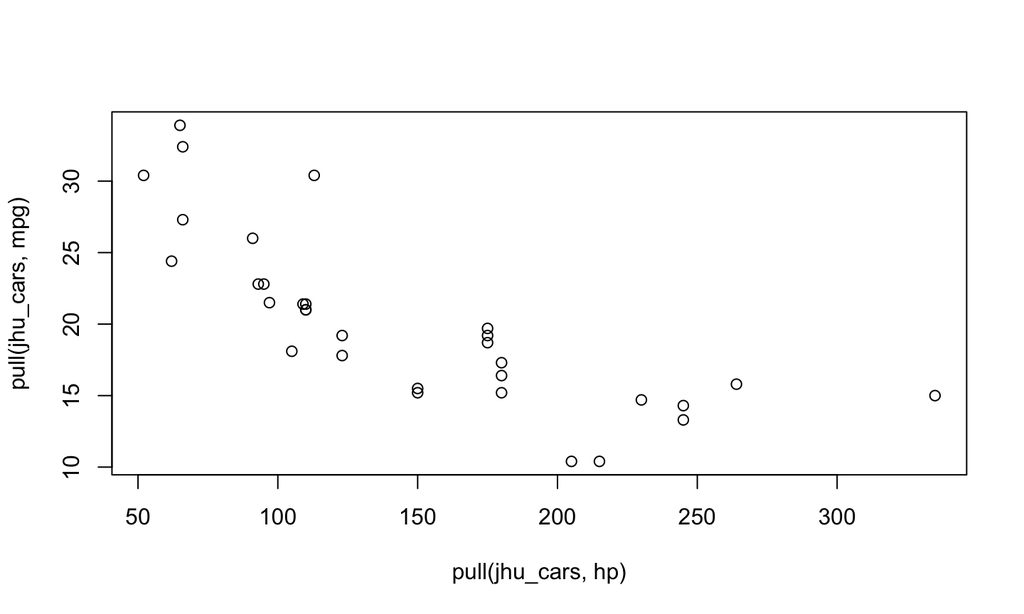

```r
plot( pull(jhu_cars,hp), pull(jhu_cars,mpg) ) # alt: plot(jhu_cars$hp, jhu_cars$mpg)
```

## Boxplot

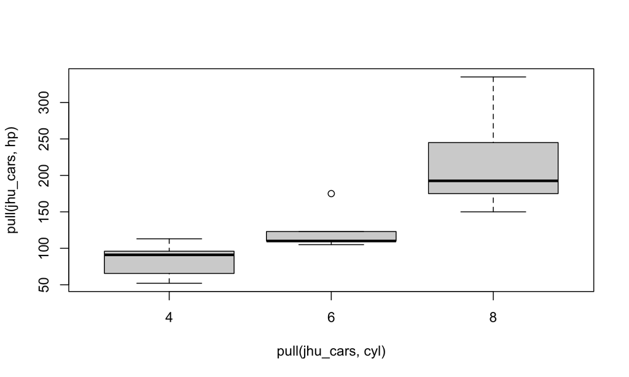

```r
boxplot( pull(jhu_cars,hp) ~ pull(jhu_cars,cyl) )
```

## Histogram

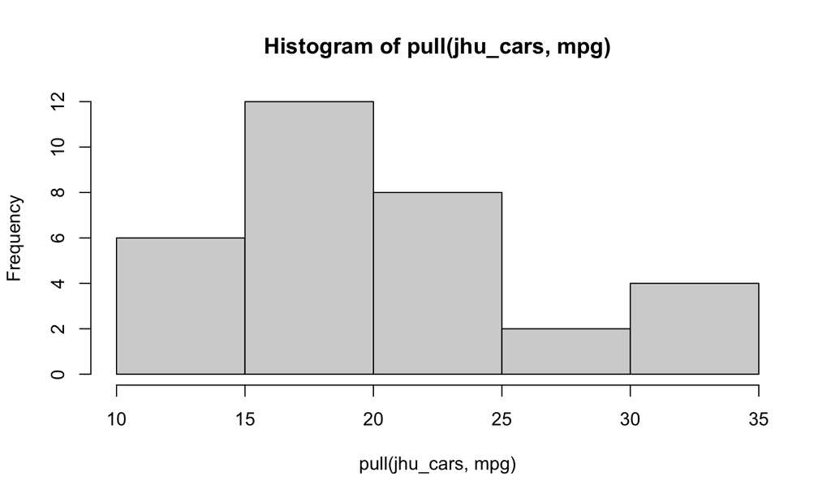

```r
hist(pull(jhu_cars,mpg))
```

## Histogram

Use the `breaks =` argument to tweak the resolution:

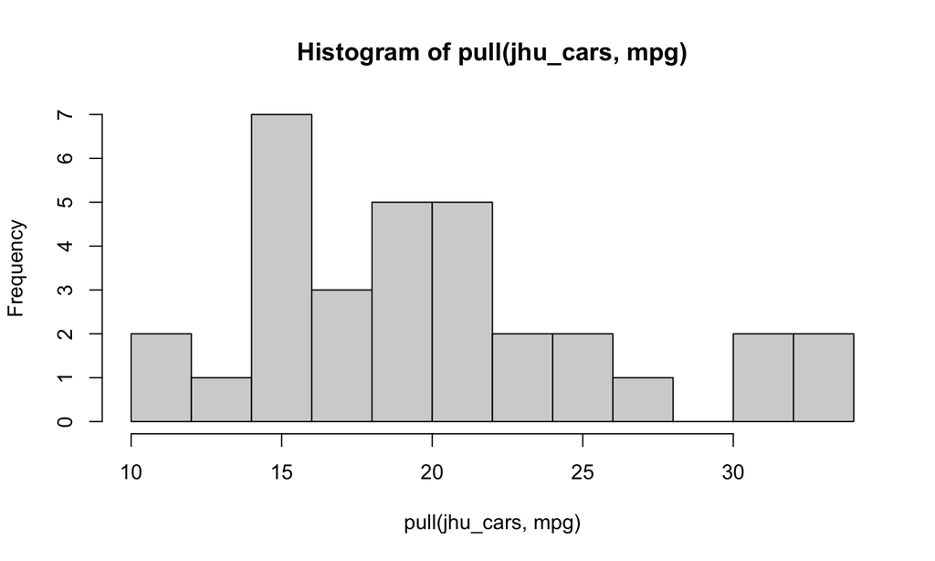

```r
hist(pull(jhu_cars,mpg), breaks = 10)
```

## Density

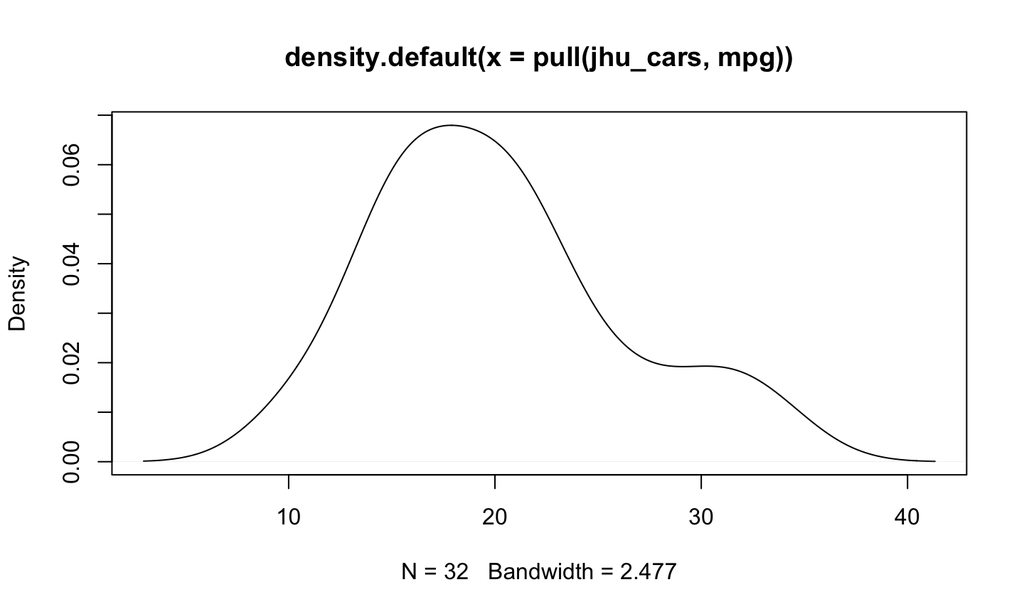

```r
plot(density(pull(jhu_cars,mpg)))
```

## Lab Part 3

[Website](http://jhudatascience.org/intro_to_R_class/index.html)